# Prem-MovieLens-Project

### `Project - MovieLens Data Analysis`

The GroupLens Research Project is a research group in the Department of Computer Science and Engineering at the University of Minnesota. The data is widely used for collaborative filtering and other filtering solutions. However, we will be using this data to act as a means to demonstrate our skill in using Python to “play” with data.

### `Objective:`

- To implement the techniques learnt as a part of the course.

### `Datasets Information:`

*rating.csv:* It contains information on ratings given by the users to a particular movie.

- user id: id assigned to every user
- movie id: id assigned to every movie
- rating: rating given by the user
- timestamp: Time recorded when the user gave a rating

*movie.csv:* File contains information related to the movies and their genre.

- movie id: id assigned to every movie
- movie title: Title of the movie
- release date: Date of release of the movie
- Action: Genre containing binary values (1 - for action 0 - not action)
- Adventure: Genre containing binary values (1 - for adventure 0 - not adventure)
- Animation: Genre containing binary values (1 - for animation 0 - not animation)
- Children’s: Genre containing binary values (1 - for children's 0 - not children's)
- Comedy: Genre containing binary values (1 - for comedy 0 - not comedy)
- Crime: Genre containing binary values (1 - for crime 0 - not crime)
- Documentary: Genre containing binary values (1 - for documentary 0 - not documentary)
- Drama: Genre containing binary values (1 - for drama 0 - not drama)
- Fantasy: Genre containing binary values (1 - for fantasy 0 - not fantasy)
- Film-Noir: Genre containing binary values (1 - for film-noir 0 - not film-noir)
- Horror: Genre containing binary values (1 - for horror 0 - not horror)
- Musical: Genre containing binary values (1 - for musical 0 - not musical)
- Mystery: Genre containing binary values (1 - for mystery 0 - not mystery)
- Romance: Genre containing binary values (1 - for romance 0 - not romance)
- Sci-Fi: Genre containing binary values (1 - for sci-fi 0 - not sci-fi)
- Thriller: Genre containing binary values (1 - for thriller 0 - not thriller)
- War: Genre containing binary values (1 - for war 0 - not war)
- Western: Genre containing binary values (1 - for western - not western)

*user.csv:* It contains information of the users who have rated the movies.

- user id: id assigned to every user
- age: Age of the user
- gender: Gender of the user
- occupation: Occupation of the user
- zip code: Zip code of the use

**`Please provide your insights wherever necessary.`**

### `Learning Outcomes:`

- Exploratory Data Analysis
- Visualization using Python
- Pandas – groupby, merging

### `Domain`

- Internet and Entertainment

**Note that the project will need you to apply the concepts of groupby and merging extensively.**

### 1. Import the necessary packages - 2.5 marks

```python
import numpy as np
import pandas as pd

import matplotlib.pyplot as plt
%matplotlib inline

import seaborn as sns
sns.set_style('darkgrid')
```

### 2. Read the 3 datasets into dataframes - 2.5 marks

```python
df_users = pd.read_csv('user.csv')
df_users.rename(columns = {'user id':'userid','zip code':'zipcode'},inplace=True)

df_movies = pd.read_csv('item.csv', parse_dates=['release date'])
df_movies.rename(columns = {'movie id':'movieid','movie title':'movietitle','release date':'reldate',
                           'Film-Noir':'FilmNoir','Sci-Fi':'SciFi'},inplace=True)

df_data = pd.read_csv('data.csv',parse_dates=['timestamp'])
df_data.rename(columns = {'user id':'userid','movie id':'movieid'},inplace=True)
```

### 3. Apply info, shape, describe, and find the number of missing values in the data. Present at least 3 observations from these operations - 2.5 marks

- Note that you will need to do it for all the three datasets seperately

```python
df_users.info()
print("Shape: ",df_users.shape,"\n---")

df_movies.info()
print("Shape: ",df_movies.shape,"\n---")

df_data.info()
print("Shape: ",df_data.shape,"\n---")
print("\n\n")
print(df_users.describe().transpose(),"\n")
print(df_movies.describe().transpose().sort_values(by='mean',ascending=False),"\n")
print(df_data.describe().transpose(),"\n")
```

```
<class 'pandas.core.frame.DataFrame'>
RangeIndex: 943 entries, 0 to 942
Data columns (total 5 columns):
userid        943 non-null int64
age           943 non-null int64
gender        943 non-null object
occupation    943 non-null object
zipcode       943 non-null object
dtypes: int64(2), object(3)
memory usage: 36.9+ KB
Shape:  (943, 5)
---
<class 'pandas.core.frame.DataFrame'>
RangeIndex: 1681 entries, 0 to 1680
Data columns (total 22 columns):
movieid        1681 non-null int64
movietitle     1681 non-null object
reldate        1681 non-null datetime64[ns]
unknown        1681 non-null int64
Action         1681 non-null int64
Adventure      1681 non-null int64
Animation      1681 non-null int64
Childrens      1681 non-null int64
Comedy         1681 non-null int64
Crime          1681 non-null int64
Documentary    1681 non-null int64
Drama          1681 non-null int64
Fantasy        1681 non-null int64
FilmNoir       1681 non-null int64
Horror         1681 non-null int64
Musical        1681 non-null int64
Mystery        1681 non-null int64
Romance        1681 non-null int64
SciFi          1681 non-null int64
Thriller       1681 non-null int64
War            1681 non-null int64
Western        1681 non-null int64
dtypes: datetime64[ns](1), int64(20), object(1)
memory usage: 289.0+ KB
Shape:  (1681, 22)
```

[output cut: 30 more lines]

```
Horror       1681.0    0.054729    0.227519  0.0    0.0    0.0     0.0     1.0
War          1681.0    0.042237    0.201189  0.0    0.0    0.0     0.0     1.0
Mystery      1681.0    0.036288    0.187061  0.0    0.0    0.0     0.0     1.0
Musical      1681.0    0.033314    0.179507  0.0    0.0    0.0     0.0     1.0
Documentary  1681.0    0.029744    0.169931  0.0    0.0    0.0     0.0     1.0
Animation    1681.0    0.024985    0.156126  0.0    0.0    0.0     0.0     1.0
Western      1681.0    0.016062    0.125751  0.0    0.0    0.0     0.0     1.0
FilmNoir     1681.0    0.014277    0.118667  0.0    0.0    0.0     0.0     1.0
Fantasy      1681.0    0.013087    0.113683  0.0    0.0    0.0     0.0     1.0
unknown      1681.0    0.000595    0.024390  0.0    0.0    0.0     0.0     1.0

            count       mean         std  min    25%    50%    75%     max
userid   100000.0  462.48475  266.614420  1.0  254.0  447.0  682.0   943.0
movieid  100000.0  425.53013  330.798356  1.0  175.0  322.0  631.0  1682.0
rating   100000.0    3.52986    1.125674  1.0    3.0    4.0    4.0     5.0
```

### 4. Find the number of movies per genre using the item data - 2.5 marks

```python
df_movies.sum()
```

```
movieid                                                  1415136
movietitle     Toy Story GoldenEye Four Rooms Get Shorty Copy...
unknown                                                        1
Action                                                       251
Adventure                                                    135
Animation                                                     42
Childrens                                                    122
Comedy                                                       505
Crime                                                        109
Documentary                                                   50
Drama                                                        725
Fantasy                                                       22
FilmNoir                                                      24
Horror                                                        92
Musical                                                       56
Mystery                                                       61
Romance                                                      247
SciFi                                                        101
Thriller                                                     251
War                                                           71
Western                                                       27
dtype: object
```

**Insights:**

1. As we inferred using describe() method, movies in Drama genre top the list at 725 movies
2. There is just 1 movie in unknown category - could be a data issue

### 5. Drop the movie where the genre is unknown - 2.5 marks

```python
# df_movies[df_movies.unknown == 1]
df_movies.drop(df_movies[df_movies.unknown == 1].index, inplace=True)
```

**Insights:** None

### 6. Find the movies that have more than one genre - 5 marks

hint: use sum on the axis = 1

Display movie name, number of genres for the movie in dataframe

and also print(total number of movies which have more than one genres)

```python
dfmvgnr = df_movies.set_index('movietitle')
dfmvgnr.drop(['movieid','reldate','unknown'],axis=1,inplace=True)
dfmvgnr.replace([0],np.NaN, inplace=True)
dfmvgnr['genretotal'] = dfmvgnr.count(1)
dfmvgnr = dfmvgnr.reset_index()
# print(dfmvgnr[['movietitle','genretotal']],"\n")
dfmvgnr[['movietitle','genretotal']][dfmvgnr.genretotal > 1].sort_values(by='genretotal', ascending=False)
```

|  | movietitle | genretotal |
| --- | --- | --- |
| 171 | Empire Strikes Back, The | 6 |
| 558 | Kid in King Arthur's Court, A | 6 |
| 424 | Transformers: The Movie, The | 6 |
| 753 | Jumanji | 5 |
| 16 | From Dusk Till Dawn | 5 |
| 818 | Space Jam | 5 |
| 100 | Heavy Metal | 5 |
| 1074 | Pagemaster, The | 5 |
| 180 | Return of the Jedi | 5 |
| 20 | Muppet Treasure Island | 5 |
| 49 | Star Wars | 5 |
| 183 | Army of Darkness | 5 |
| 853 | Diva | 5 |
| 991 | Hercules | 5 |
| 421 | E.T. the Extra-Terrestrial | 4 |
| 244 | Devil's Own, The | 4 |
| 1089 | Pete's Dragon | 4 |
| 256 | Men in Black | 4 |
| 1108 | Tank Girl | 4 |
| 768 | Devil in a Blue Dress | 4 |
| 251 | Lost World: Jurassic Park, The | 4 |
| 800 | Hard Target | 4 |
| 767 | Congo | 4 |
| 259 | Event Horizon | 4 |
| 94 | Aladdin | 4 |
| 140 | 20,000 Leagues Under the Sea | 4 |
| 409 | Nutty Professor, The | 4 |
| 943 | Charade | 4 |
| 134 | 2001: A Space Odyssey | 4 |
| 131 | Wizard of Oz, The | 4 |
| ... | ... | ... |
| 725 | Immortal Beloved | 2 |
| 726 | Junior | 2 |
| 728 | Queen Margot (Reine Margot, La) | 2 |
| 158 | Basic Instinct | 2 |
| 730 | Dave | 2 |
| 731 | Go Fish | 2 |
| 734 | Shadowlands | 2 |
| 735 | Sirens | 2 |
| 736 | Threesome | 2 |
| 737 | Pretty Woman | 2 |
| 738 | Jane Eyre | 2 |
| 717 | Canadian Bacon | 2 |
| 715 | Juror, The | 2 |
| 714 | Home for the Holidays | 2 |
| 693 | Kicking and Screaming | 2 |
| 683 | Executive Decision | 2 |
| 684 | Perfect World, A | 2 |
| 685 | McHale's Navy | 2 |
| 687 | Jackal, The | 2 |
| 688 | Seven Years in Tibet | 2 |
| 168 | Wrong Trousers, The | 2 |
| 694 | City Hall | 2 |
| 713 | To Die For | 2 |
| 700 | Barcelona | 2 |
| 702 | House of the Spirits, The | 2 |
| 703 | Singin' in the Rain | 2 |
| 707 | Strictly Ballroom | 2 |
| 710 | Tin Men | 2 |
| 712 | Carrington | 2 |
| 1678 | Sliding Doors | 2 |

849 rows × 2 columns

**Insights:** There are different ways of solving this problem; I found replacing the 'zeros' with null values help in using available functions for counting across columns

### 7. Univariate plots of columns: 'rating', 'Age', 'release year', 'Gender' and 'Occupation' - 10 marks

*HINT: Use distplot for age and countplot for release year, ratings,*

*HINT: Please refer to the below snippet to understand how to get to release year from release date. You can use str.split() as depicted below or you could convert it to pandas datetime format and extract year (.dt.year)*

```python
a = 'My*cat*is*brown'
print(a.split('*')[3])

#similarly, the release year needs to be taken out from release date

#also you can simply slice existing string to get the desired data, if we want to take out the colour of the cat

print(a[10:])
print(a[-5:])
```

```
brown
brown
brown
```

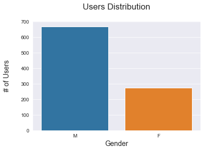

```python
sns.countplot(x='gender',data=df_users);
plt.title('Users Distribution\n', fontdict={'fontsize': 17})
plt.xlabel('Gender',size=14)
plt.ylabel('# of Users\n',size=14)
```

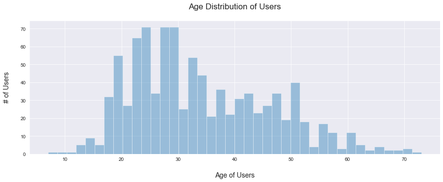

```python
plt.figure(figsize=[15,5])
sns.distplot(df_users.age, bins=40, kde=False);
plt.title('Age Distribution of Users\n', fontdict={'fontsize': 17})
plt.xlabel('\nAge of Users',size=14)
plt.ylabel('# of Users\n',size=14)
```

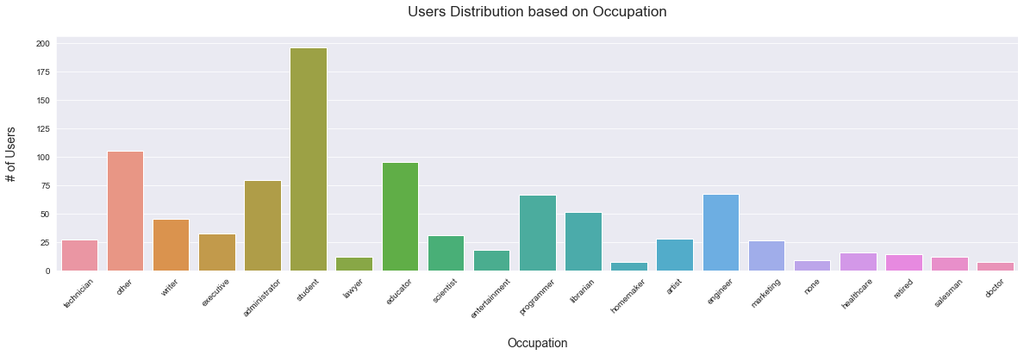

```python
plt.figure(figsize=[20,5])
sns.countplot(x='occupation',data=df_users);
plt.title('Users Distribution based on Occupation\n', fontdict={'fontsize':17})
plt.xticks(rotation=45)
plt.xlabel('\nOccupation',size=14)
plt.ylabel('# of Users\n',size=14)
```

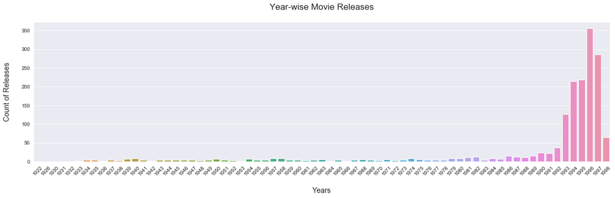

```python
plt.figure(figsize=[20,5])
sns.countplot(x=pd.DatetimeIndex(df_movies.reldate).year,data=df_movies);
plt.xticks(rotation=45)
plt.title('Year-wise Movie Releases\n', fontdict={'fontsize': 17})
plt.xlabel('\nYears',size=14)
plt.ylabel('Count of Releases\n',size=14)
```

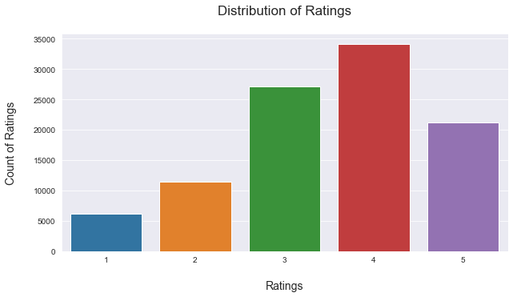

```python
plt.figure(figsize=[10,5])
sns.countplot(x='rating',data=df_data);
plt.title('Distribution of Ratings\n', fontdict={'fontsize': 17})
plt.xlabel('\nRatings',size=14)
plt.ylabel('Count of Ratings\n',size=14)
```

### 8. Visualize how popularity of genres has changed over the years - 10 marks

Note that you need to use the **percent of number of releases in a year** as a parameter of popularity of a genre

Hint 1: You need to reach to a data frame where the release year is the index and the genre is the column names (one cell shows the number of release in a year in one genre) or vice versa. (Drop unnecessary column if there are any)

Hint 2: Find the total number of movies release in a year(use item dataset to get count of movies released in a particular year, store that value in a new column as 'total'). Now divide the value of each genre in that year by total to get percentage number of release in a particular year. `(df.div(df['total'], axis= 0) * 100)`

Once that is achieved, you can either use univariate plots or can use the heatmap to visualise all the changes over the years in one go.

Hint 3: Use groupby on the relevant column and use sum() on the same to find out the number of releases in a year/genre.

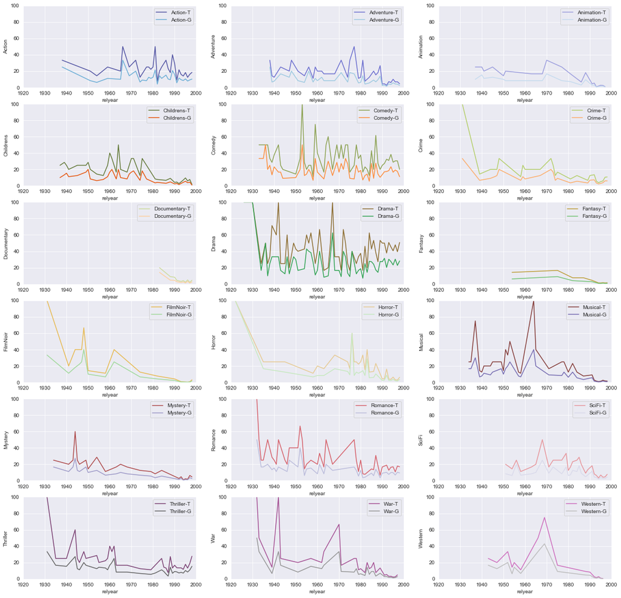

```python
#your code here
df_movies['relyear'] = pd.DatetimeIndex(df_movies.reldate).year
dfpop = df_movies.groupby('relyear').agg (
                                    {
                                        'movieid':'count',
                                        'Action':sum,
                                        'Adventure':sum,
                                        'Animation':sum,
                                        'Childrens':sum,
                                        'Comedy':sum,
                                        'Crime':sum,
                                        'Documentary':sum,
                                        'Drama':sum,
                                        'Fantasy':sum,
                                        'FilmNoir':sum,
                                        'Horror':sum,
                                        'Musical':sum,
                                        'Mystery':sum,
                                        'Romance':sum,
                                        'SciFi':sum,
                                        'Thriller':sum,
                                        'War':sum,
                                        'Western':sum
                                    }
                            ).rename(columns={'movieid':'yrtotal'})
dfpop = dfpop.reset_index()
dfpop.set_index(['relyear','yrtotal'],inplace=True)
dfpop['gnrtotal'] =  dfpop.sum(1)
dfpop = dfpop.reset_index()
dfpop.set_index(['relyear','yrtotal','gnrtotal'],inplace=True)

dfpop1prcnt = dfpop.copy()
dfpop1prcnt = dfpop1prcnt.reset_index()
dfpop1prcnt.set_index(['relyear','gnrtotal'],inplace=True)
dfpop1prcnt = dfpop1prcnt.div(dfpop1prcnt.yrtotal,axis=0)*100
dfpop1prcnt = dfpop1prcnt.reset_index()
dfpop1prcnt = dfpop1prcnt.drop(['yrtotal','gnrtotal'],axis=1)
dfpop1prcnt.replace([0],np.NaN, inplace=True)

dfpop2prcnt = dfpop.copy()
dfpop2prcnt = dfpop2prcnt.reset_index()
dfpop2prcnt.set_index(['relyear','yrtotal'],inplace=True)
dfpop2prcnt = dfpop2prcnt.div(dfpop2prcnt.gnrtotal,axis=0)*100
dfpop2prcnt = dfpop2prcnt.reset_index()
dfpop2prcnt = dfpop2prcnt.drop(['yrtotal','gnrtotal'],axis=1)
dfpop2prcnt.replace([0],np.NaN, inplace=True)

palette1=plt.get_cmap('tab20b')
palette2=plt.get_cmap('tab20c')
num=0
plt.figure(figsize=[20,20])
for col in dfpop1prcnt.drop('relyear',axis=1) :
    num += 1
    plt.subplot(6,3,num)
    sns.lineplot(dfpop1prcnt.relyear, dfpop1prcnt[col],color=palette1(num), marker='', label=(col+'-T'))
    sns.lineplot(dfpop2prcnt.relyear, dfpop2prcnt[col],color=palette2(num), marker='', label=(col+'-G'))
    plt.xlim(1920,2000)
    plt.ylim(0,100)
```

**Insights:**

1. While the Hints/suggestions call for calculating the % using the total movies for the year, I would rather use the Genre total for the year to get a proper distribution - given movies are tagged with multiple genres.
2. For comparison, I have added the line plot of percentages using the Movie Totals marked with '-T' and line plot of percentages using the Genre Totals marked with '-G'

### 9. Find the top 25 movies in terms of average ratings for movies that have been rated more than 100 times - 10 marks

Hints :

1. Find the count of ratings and average ratings for every movie.
2. Slice the movies which have ratings more than 100.
3. Sort values according to average rating such that movie which highest rating is on top.
4. Select top 25 movies.
5. You will have to use the .merge() function to get the movie titles.

Note: This question will need you to research about groupby and apply your findings. You can find more on groupby on https://realpython.com/pandas-groupby/.

```python
#your code here
df_data.head()
dfrtng = df_data.groupby('movieid').agg(
    {
        'userid':'count',
        'rating':'mean'
    }
).rename(columns={'userid':'numrtng','rating':'avgrtng'})
df100rtng = dfrtng[dfrtng.numrtng > 100]
df100rtng = df100rtng.reset_index()
df100rtng = df100rtng.merge(df_movies[['movieid','movietitle']],how='left',on='movieid')
df100rtng[['movietitle','avgrtng','numrtng']].sort_values(by='avgrtng',ascending=False).head(25)
```

|  | movietitle | avgrtng | numrtng |
| --- | --- | --- | --- |
| 231 | Close Shave, A | 4.491071 | 112 |
| 202 | Schindler's List | 4.466443 | 298 |
| 91 | Wrong Trousers, The | 4.466102 | 118 |
| 261 | Casablanca | 4.456790 | 243 |
| 29 | Shawshank Redemption, The | 4.445230 | 283 |
| 292 | Rear Window | 4.387560 | 209 |
| 7 | Usual Suspects, The | 4.385768 | 267 |
| 22 | Star Wars | 4.358491 | 583 |
| 99 | 12 Angry Men | 4.344000 | 125 |
| 72 | Citizen Kane | 4.292929 | 198 |
| 238 | To Kill a Mockingbird | 4.292237 | 219 |
| 219 | One Flew Over the Cuckoo's Nest | 4.291667 | 264 |
| 55 | Silence of the Lambs, The | 4.289744 | 390 |
| 259 | North by Northwest | 4.284916 | 179 |
| 68 | Godfather, The | 4.283293 | 413 |
| 182 | Secrets & Lies | 4.265432 | 162 |
| 173 | Good Will Hunting | 4.262626 | 198 |
| 298 | Manchurian Candidate, The | 4.259542 | 131 |
| 254 | Dr. Strangelove or: How I Learned to Stop Worr... | 4.252577 | 194 |
| 95 | Raiders of the Lost Ark | 4.252381 | 420 |
| 258 | Vertigo | 4.251397 | 179 |
| 198 | Titanic | 4.245714 | 350 |
| 271 | Lawrence of Arabia | 4.231214 | 173 |
| 262 | Maltese Falcon, The | 4.210145 | 138 |
| 93 | Empire Strikes Back, The | 4.204360 | 367 |

### 10. Check for the validity of the below statements with respect to the data provided - 10 marks

- Men watch more drama than women
- Women watch more Sci-Fi than men
- Men watch more Romance than women

**compare the percentages**

**Please pay attention to what should be the denominator while calculating percentages**

1. Merge all the datasets
2. There is no need to conduct statistical tests around this. Just **compare the percentages** and comment on the validity of the above statements.
3. you might want ot use the .sum(), .div() function here.
4. Use number of ratings to validate the numbers. For example, if out of 4000 ratings received by women, 3000 are for drama, we will assume that 75% of the women watch drama.

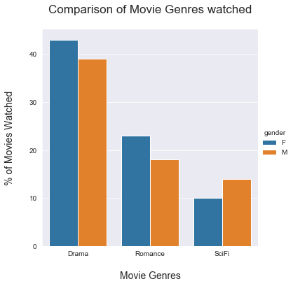

```python
#your code here
df = df_data.merge(df_movies, how='left', on='movieid')
df = df.merge(df_users, how='left', on='userid')
df.drop(df[df.movietitle.isnull()].index, inplace=True)

dfgndr = df.groupby('gender',as_index=False).agg(
    {
        'Drama':sum,
        'Romance':sum,
        'SciFi':sum,
        'movieid':'count'
    }
).rename(columns={'Drama':'D','Romance':'R','SciFi':'S','movieid':'totalmovie'})
dfgndr['Drama'] = round(dfgndr.D/dfgndr.totalmovie*100,0)
dfgndr['Romance'] = round(dfgndr.R/dfgndr.totalmovie*100,0)
dfgndr['SciFi'] = round(dfgndr.S/dfgndr.totalmovie*100,0)

dfpct = dfgndr[['gender','Drama','Romance','SciFi']]
dfpct = dfpct.melt(id_vars=['gender'],value_vars=['Drama','Romance','SciFi'],
                   var_name='genre', value_name='pct')

plt.figure(figsize=[10,6])
sns.catplot(x='genre',y='pct',data=dfpct,hue='gender',kind='bar');
plt.xlabel('\nMovie Genres',size=14)
plt.ylabel('% of Movies Watched\n',size=14)
plt.title('Comparison of Movie Genres watched\n',size=17)
```

**Conclusion:** Based on the assumption of considering the gender of movie rating submission user the same as the gender of user watching the movie

1. Men DON'T watch more Drama than women
2. Women DON'T watch more SciFi than men
3. Men DON'T watch more Romance than women